# biclustermd: An R Package for Biclustering with Missing Values

## 5 Example with soybean yield data

For our next example, we perform biclustering on a dataset which has a larger fraction of missing data to further show the practicability of our algorithm. Using data from a commercial soybean breeding program, we consider 132 soybean varieties as rows, 73 locations as columns, and yield in bushels per acre as the response. The locations span across the Midwestern United States and includes parts of Illinois, Iowa, Minnesota, Nebraska, and South Dakota, and each of the 132 soybean varieties represent a different genetic make-up. As one can imagine, not every soybean is grown in each location, as such we obtain a dataset with approximately 72.9% missing values. One application of a dataset such as this would be to determine if there are some subset of soybeans that perform consistently better (or worse) in some locations than others. From a plant breeding perspective, it is of vital importance to understand the relationship between the genetics and environments of crops, and identifying cells non-overlapping homogeneous cells from biclustering can provide insights into this matter (Malosetti et al. 2013).

The main purpose of this dataset is to demonstrate our algorithm on a dataset with a large amount of missing values as well as show the usefulness of the tuning parameters. Below is our first trial on the soybean yield data where we partition into 10 column clusters, 11 row clusters, and use the Jaccard similarity measure.

```r
> yield_bc <- biclustermd(
+   yield,
+   col_clusters = 10,
+   row_clusters = 11,
+   similarity = "Jaccard",
+   miss_val_sd = sd(yield, na.rm = TRUE),
+   col_min_num = 3,
+   row_min_num = 3
+ )
> yield_bc

Data has 9636 values, 72.9% of which are missing
13 Iterations
Initial SSE = 239166; Final SSE = 51813, a 78.3% reduction
Jaccard similarity used; Indices: Columns (P) = 1, Rows (Q) = 1
```

In observing Figure 10, we notice that perfect convergence through the Rand Index, adjusted Rand Index, and Jaccard similarity; however, the similarities suggest that the columns converge more quickly than the rows. This may be attributed to the high percentage of missing values in the rows of the data table. That is, for each location there is more data available than there is for each soybean variety. Again we notice decreases in the values for each of the three indices, but observing Figure 11, we are assured that the algorithm is only making a column/row swap because a lower SSE is obtainable.

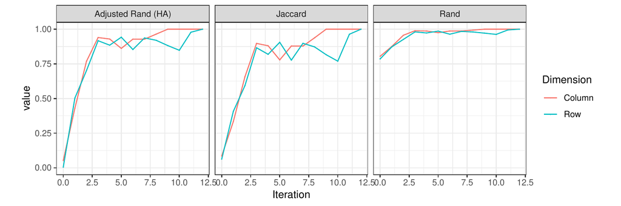

Figure 10: Plot of similarity measures for the soybean yield biclustering

```r
> autoplot(yield_bc$Similarities, facet = TRUE, ncol = 3, size = 0) +
+   theme_bw() +
+   theme(aspect.ratio =  1)
```

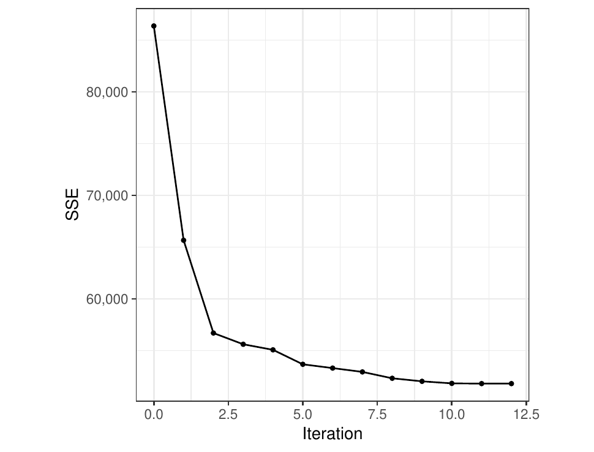

Figure 11: SSE plot of soybean yield biclustering

```r
> autoplot(yield_bc$SSE, size = 1) +
+   theme_bw() +
+   theme(aspect.ratio =  1) +
+   scale_y_continuous(labels = comma)
```

For the initial trial we observe that the Jaccard index converges in 13 iterations to an SSE value of 51,813. To see if it is possible to decrease this SSE even further, we test the impact of `col_shuffles` and `row_shuffles`. Recall that these parameters determine how many row and column rearrangements the algorithm makes before completing *one* iteration. Below we use `tune_biclustermd()` to test combinations of `col_shuffles` and `row_shuffles` as well as its corresponding SSE. We define the tune grid to mimic that of the `yield_bc` creation above, but let `col_shuffles` and `row_shuffles` take on values in $\{1, 3, 6\}$ independent of each other. We repeat the biclustering ten times for each parameter, specified by `nrep = 10`. Note that `parallel = TRUE` allows us to tune over the grid in parallel.

```r
> yield_tbc <- tune_biclustermd(
+   yield,
+   nrep = 10,
+   tune_grid = expand.grid(
+     col_clusters = 10,
+     row_clusters = 11,
+     similarity = "Jaccard",
+     miss_val_sd = sd(yield, na.rm = TRUE),
+     col_min_num = 3,
+     row_min_num = 3,
+     row_shuffles = c(1, 3, 6),
+     col_shuffles = c(1, 3, 6)
+   ),
+   parallel = TRUE,
+   ncores = 2
+ )
> yield_tbc$grid[, c('row_shuffles', 'col_shuffles', 'min_sse', 'sd_sse', 'best_combn')]
    row_shuffles col_shuffles  min_sse   sd_sse best_combn
  1            1            1 51202.74 2640.662
  2            3            1 54073.92 2766.218
  3            6            1 52203.23 3198.391
  4            1            3 51296.99 1883.676
  5            3            3 52869.85 2118.745
  6            6            3 50530.38 2107.578 *
  7            1            6 51442.19 1895.268
  8            3            6 52111.31 2015.416
  9            6            6 52870.18 2652.400
```

## 6 Algorithm time study with movie ratings data

For our last example, we focus our attention on a movie ratings dataset obtained from MovieLens (Harper and Konstan 2015). If we consider movie raters as defining rows, movies as defining columns, and a rating from 1–5 (with 5 being the most favorable) as a response, then biclustering can be used to determine subsets of raters who have similar preferences towards some subset of movies.

The main topic of this section will be to perform time studies to test the scalability of our proposed algorithm. In some applications, it is not uncommon to have a two-way data table with 10,000+ rows or columns. Intuitively as the dimensions of the two-way data table increases so will the computational time. In it is not uncommon for other biclustering algorithms to run for 24+ hours (Oghabian 2014). We ran the biclustering over a grid of 80 combinations of $I$ rows, $J$ columns, $r$ row clusters, and $c$ column clusters with 30 replications for each combination. In addition to the four grid parameters, we consider the following metrics which are byproducts of the four parameters: the size of the dataset $N = I \times J$, average row cluster size $I / r$, and average column cluster size $J / c$. Table 1 summarizes the grid parameters, their byproducts and the defined lower and upper limits on each.

Table 1: Summary of the movie data runtime grid with defined lower and upper limits

|  | $N = I \times J$ | $I$ | $J$ | $r$ | $c$ | $I / r$ | $J / c$ |
| --- | --- | --- | --- | --- | --- | --- | --- |
| Lower Limit | 2,500 | 50 | 50 | 4 | 4 | 5 | 5 |
| Min | 18,146 | 86 | 98 | 4 | 4 | 5 | 5 |
| Mean | 665,842 | 784 | 839 | 42 | 45 | 49 | 47 |
| Max | 1,929,708 | 1,495 | 1,457 | 239 | 258 | 293 | 346 |
| Upper Limit | 2,225,000 | 1,500 | 1,500 | 300 | 300 | 375 | 375 |

Table 2 gives a five number summary and the mean runtime in seconds paired with the parameters which produced run times closest to each statistic. In all, we see that the algorithm can take less than a second to run, while in the other extreme the algorithm requires 39 minutes to converge. It is particularly interesting that for the two parameter combinations closest to the median run time, one dataset is nearly twice the size of the other. Furthermore, note than the mean run time is more than twice that of the median, but the size of the dataset is just 38% of that at the median. However, at the mean, $3744 = 72 \cdot 52$ biclusters are computed, while at the medians, only $80 = 20 \cdot 4$ and $481 = 13 \cdot 37$ biclusters are computed. For a visual summary of the results, we point the reader to Figure 12.

Table 2: Five number summary and mean runtime in seconds along with parameters achieved at

|  | Seconds | $I$ | $J$ | $N$ | $r$ | $c$ | Sparsity |
| --- | --- | --- | --- | --- | --- | --- | --- |
| Min | 0.4 | 210 | 98 | 20,580 | 10 | 9 | 96.2% |
| Q1 | 24.7 | 820 | 184 | 150,880 | 53 | 12 | 98.2% |
| Median | 63.6 | 988 | 1,240 | 1,225,120 | 20 | 4 | 98.5% |
| Median | 63.5 | 501 | 1,302 | 652,302 | 13 | 37 | 98.0% |
| Mean | 137.5 | 1,084 | 427 | 462,868 | 72 | 52 | 98.4% |
| Q3 | 141.0 | 485 | 875 | 424,375 | 36 | 126 | 98.0% |
| Max | 2,369.0 | 1,495 | 1,233 | 1,843,335 | 147 | 204 | 98.5% |

Figure 12 plots run times versus the five parameters controlled for in the study as well as average row cluster size, average column cluster size, and sparsity. We encourage the reader to personally explore the results; the run time data is the `runtimes` dataset in the package. Moreover, (Li et al. 2020), provides further insights into the effect of sparsity on runtimes.

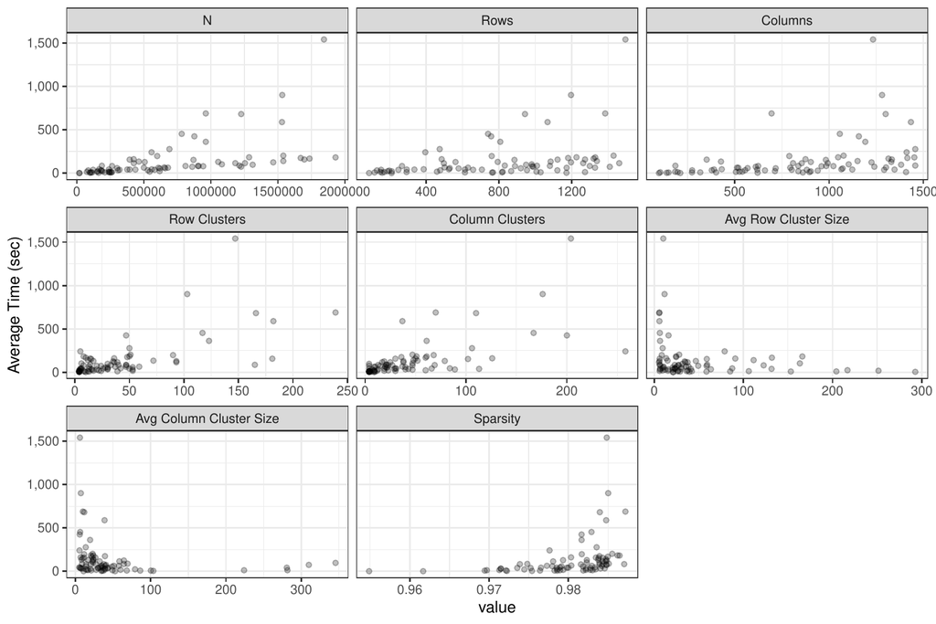

Figure 12: Relationship between movie grid parameters and elapsed time

Finally, we address the trade-off between interpretability and computation time. Figure 13 plots elapsed time versus average cluster size on a doubly $\log10$ scales for row clusters (left) and column clusters (right). Clearly, computation time can be decreased by increasing the average cluster size, but doing so potentially reduces the interpretability of results; biclusters may be too large for certain use cases. Keeping in mind that the $y$-axis is on a $\log10$ scale, increasing average cluster size will have diminishing returns. Reviewing the plot on the right-hand side of the second row and the left-hand side of row three in Figure 12 sheds more light into this notion.

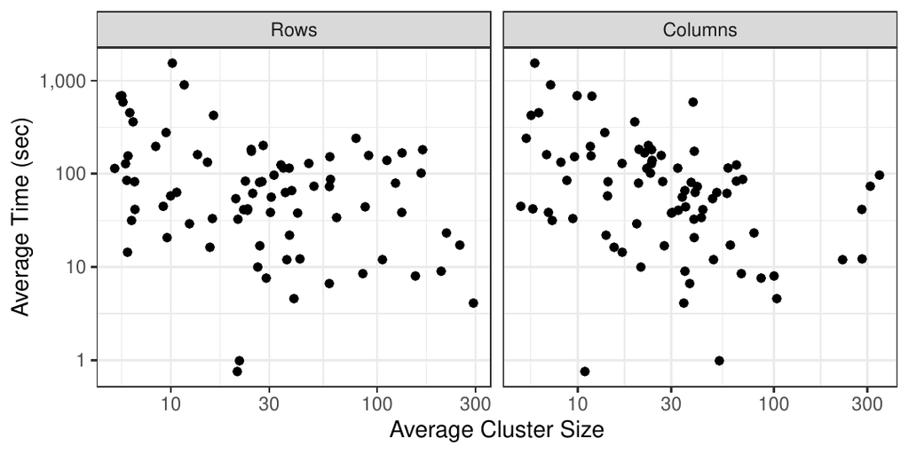

Figure 13: Relationship between average cluster sizes and elapsed time

## 7 Summary

Based on the work of (Li et al. 2020) we provide a user-friendly R implementation of their proposed biclustering algorithm for missing data as well as a variety of visual aids that are helpful for biclustering in general and biclustering with missing data specifically. The unique benefit *biclustermd* provides is in its ability to operate with missing values. Compared to other packages which do not allow incomplete data or make use of some sort of imputation, we approach this problem with a novel framework that does not alter the structure of an inputted data matrix. Moreover, given the tunability of our biclustering algorithm, users are able to run trials on numerous combinations in an attempt to best bicluster their data.

## 8 Acknowledgments

This research was supported in part by Syngenta Seeds and by a Kingland Data Analytics Faculty Fellowship at Iowa State University.

### 8.1 Supplementary materials

Supplementary materials are available in addition to this article. It can be downloaded at RJ-2019-045.zip

### 8.2 CRAN packages used

biclust, superbiclust, s4vd, BiBitR, biclustermd, clues, nycflights13, tidyverse, ggplot2

### 8.3 CRAN Task Views implied by cited packages

ChemPhys, Cluster, NetworkAnalysis, Phylogenetics, Spatial, TeachingStatistics

### 8.4 Bioconductor packages used

iBBiG, QUBIC

S. Bergmann, J. Ihmels and N. Barkai. Iterative signature algorithm for the analysis of large-scale gene expression data. *Physical Review E - Statistical Physics, Plasmas, Fluids, and Related Interdisciplinary Topics*, 2003. URL https://doi.org/10.1103/PhysRevE.67.031902.

S. Busygin, O. Prokopyev and P. M. Pardalos. Biclustering in data mining. *Computers and Operations Research*, 35(9): 2008. URL https://doi.org/10.1016/j.cor.2007.01.005.

Y. Cheng and G. M. Church. Biclustering of expression data. *Proceedings International Conference on Intelligent Systems for Molecular Biology ; ISMB. International Conference on Intelligent Systems for Molecular Biology*, 8: 2000.

D. T. Ewoud. *BiBitR: R wrapper for java implementation of BiBit.* 2017. R package version 0.4.2.

D. W. Goodall. A new similarity index based on probability. *Biometrics*, 22: 882–907, 1966.

D. Gusenleitner and A. Culhane. *iBBiG: Iterative binary biclustering of genesets.* 2019. URL http://bcb.dfci.harvard.edu/~aedin/publications/. R package version 1.28.0.

F. M. Harper and J. A. Konstan. The MovieLens datasets. *ACM Transactions on Interactive Intelligent Systems*, 2015.

J. A. Hartigan. Direct clustering of a data matrix. *Journal of the American Statistical Association*, 67(337): 123–129, 1972. URL https://doi.org/10.1080/01621459.1972.10481214.

L. Hubert and P. Arabie. Comparing partitions. *Journal of Classification*, 1985. DOI 10.1007/BF01908075.

S. Kaiser and F. Leisch. A toolbox for bicluster analysis in {R}. *Compstat 2008—Proceedings in Computational Statistics*, 201–208, 2008.

T. Khamiakova. *Superbiclust: Generating robust biclusters from a bicluster set (ensemble biclustering).* 2014. URL https://CRAN.R-project.org/package=superbiclust. R package version 1.1.

Y. Kluger, R. Basri, J. T. Chang and M. Gerstein. Spectral biclustering of microarray data: Coclustering genes and conditions. *Genome Research*, 13(4): 703–716, 2003. URL https://doi.org/10.1101/gr.648603.

L. Lazzeroni and A. Owen. Plaid models for gene expression data. *Statistica Sinica*, 12: 61–86, 2002. URL https://doi.org/10.1017/CBO9781107415324.004.

J. Li, J. Reisner, H. Pham, S. Olafsson and S. Vardeman. Biclustering for missing data. *Information Sciences*, 510: 304–316, 2020. URL https://doi.org/10.1016/j.ins.2019.09.047.

M. Malosetti, J. M. Ribaut and F. A. van Eeuwijk. The statistical analysis of multi-environment data: Modeling genotype-by-environment interaction and its genetic basis. *Frontiers in Physiology*, 4(44): 2013. URL https://doi.org/10.3389/fphys.2013.00044.

S. A. H. Oghabian Ali AND Kilpinen. Biclustering methods: Biological relevance and application in gene expression analysis. *PLOS ONE*, 9(3): 1–10, 2014. URL https://doi.org/10.1371/journal.pone.0090801.

M. Rand. Objective criteria for the evaluation of methods clustering. *Journal of the American Statistical Association*, 66(336): 846–850, 1971. URL https://doi.org/10.1080/01621459.1971.10482356.

M. Sill and S. Kaiser. *s4vd: Biclustering via sparse singular value decomposition incorporating stability selection.* 2015. URL https://CRAN.R-project.org/package=s4vd. R package version 1.1-1.

K. M. Tan and D. M. Witten. Sparse Biclustering of Transposable Data. *Journal of Computational and Graphical Statistics*, 2014. URL https://doi.org/10.1080/10618600.2013.852554.

H. Wickham. *ggplot2: Elegant graphics for data analysis.* Springer-Verlag New York, 2009. URL http://ggplot2.org.

H. Wickham. *nycflights13: Flights that departed NYC in 2013.* 2017. URL https://CRAN.R-project.org/package=nycflights13. R package version 0.2.2.

H. Wickham. *tidyverse: Easily Install and Load ’Tidyverse’ Packages.* 2016. URL https://cran.r-project.org/package=tidyverse.

H. Wickham and L. Henry. *Tidyr: Easily tidy data with ’spread()’ and ’gather()’ functions.* 2019. URL https://CRAN.R-project.org/package=tidyr. R package version 0.8.3.

Y. Zhang, J. Xie, J. Yang, A. Fennell, C. Zhang and Q. Ma. QUBIC: A bioconductor package for qualitative biclustering analysis of gene co-expression data. *Bioinformatics*, 33(3): 450–452, 2017. URL https://doi.org/10.1093/bioinformatics/btw635.